# Tutorial for Causal Panel Analysis

Ziyi Liu and Yiqing Xu

In recent years, researchers have proposed various robust estimators for heterogeneous treatment effects (HTE) in causal panel analysis as an alternative to traditional two-way fixed effects (TWFE) models. Examples of these estimators include those proposed by Sun and Abraham (2021), Callaway and Sant’Anna (2021), Liu, Wang, and Xu (2022), Borusyak, Jaravel, and Spiess (2021), and Imai, Kim, and Wang (2021). This tutorial will guide you through the implementation of these HTE-robust estimators, as well as TWFE, using R. It will also provide instructions on how to create event study plots that display estimated dynamic treatment effects. Additionally, this tutorial will present a recommended pipeline for analyzing panel data, covering data exploration, estimation, result visualization, and diagnostic tests. To begin, you will need to install necessary packages from CRAN and Github. The tutorial will then provide two empirical examples, based on Hainmueller and Hangartner (2019) and Grumbach and Sahn (2020), to illustrate these methods.

# Installing Packages

```r
# install packages from CRAN
packages <- c("dplyr", "readstata13", "fixest", "did", "fect",
              "panelView", "PanelMatch", "ggplot2", "bacondecomp")
install.packages(setdiff(packages, rownames(installed.packages())))

# install "paneltools"
if ("paneltools" %in% rownames(installed.packages()) == FALSE) {
  devtools:: install_github("xuyiqing/paneltools")
}
```

```r
library(dplyr)
library(readstata13)
library(fixest)
library(did)
library(fect)
library(panelView)
library(PanelMatch)
library(ggplot2)
library(bacondecomp)
library(paneltools)
```

# Example 1: w/o Treatment Reserveal

```r
data <- read.dta13(paste0(path, "jens_ajps2019_clean.dta"))
head(data)
```

```
#>   bfs year nat_rate_ord indirect
#> 1   1 1991     0.000000        0
#> 2   1 1992     0.000000        0
#> 3   1 1993     0.000000        0
#> 4   1 1994     3.448276        0
#> 5   1 1995     0.000000        0
#> 6   1 1996     0.000000        0
```

## Data Visualization

First, we will examine the evolution of treatment status using the **panelView** package. The variables `bfs` and `year` are the unit and time indicators, respectively. The treatment variable is `indirect`, and the outcome is `nat_rate_ord`. In the baseline analysis, we will not include any covariates. We will set the option `by.timing = TRUE` to sort units by the timing of receiving the treatment.

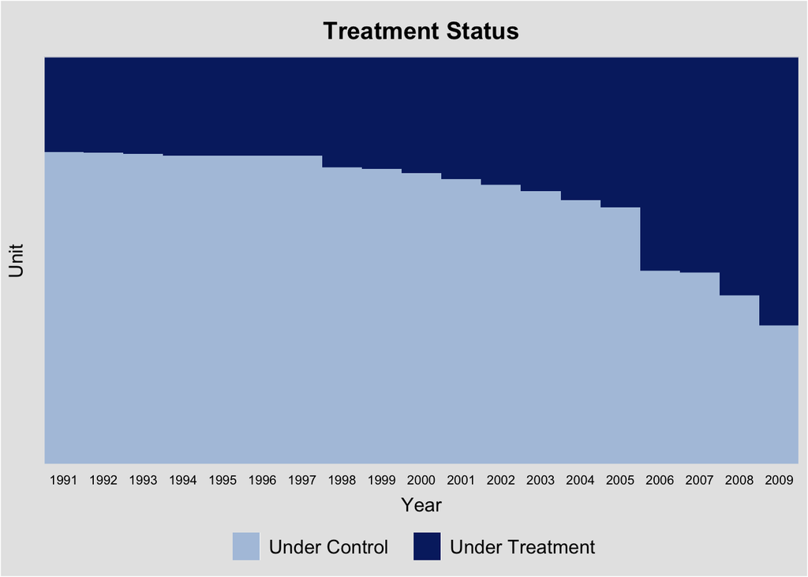

```r
panelview(nat_rate_ord ~ indirect, data = data, index = c("bfs","year"),
  xlab = "Year", ylab = "Unit", display.all = T,
  gridOff = TRUE, by.timing = TRUE)
```

The treatment status plot shows that the treatment rolls out in different years for different municipalities and there are no treatment reversals (staggered adoption). Following the definition in Sun and Abraham (2021), we define the units that take the treatment in the same year as a cohort. We can plot the average outcomes for each cohort using **panelView**.

```r
panelview(data = data,Y='nat_rate_ord',
          D='indirect',index=c("bfs","year"),
          by.timing = T, display.all = T,
          type = "outcome",by.cohort = T)
```

```
#> Number of unique treatment history: 17
```

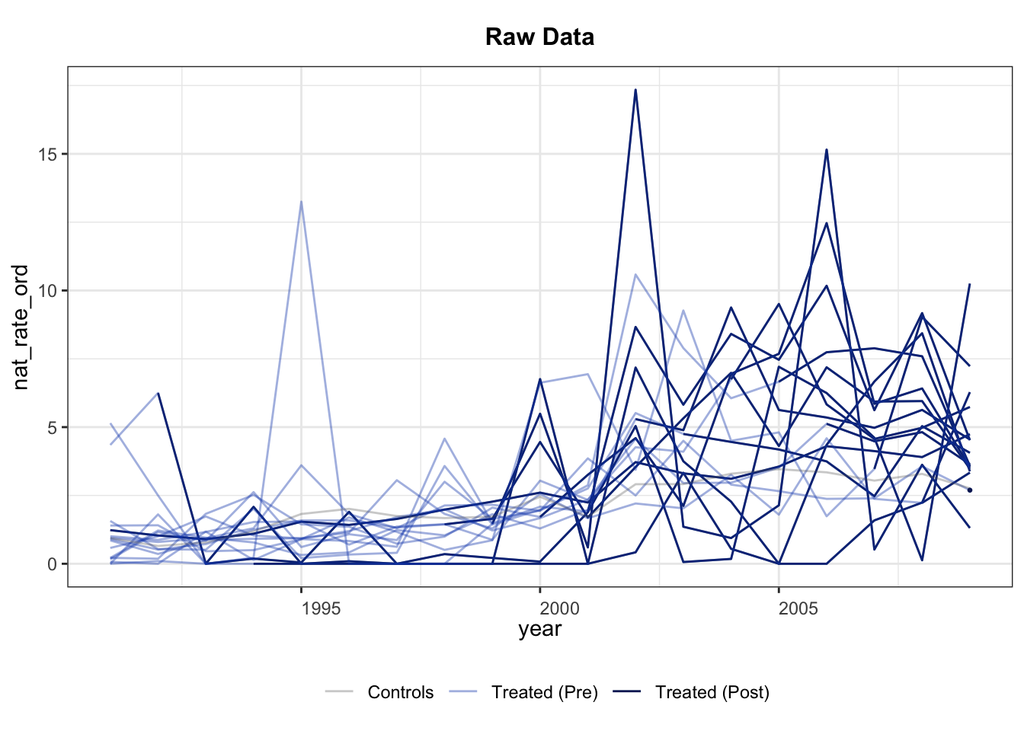

## TWFE

The staggered adoption setup allows us to implement several estimators to obtain the treatment effect estimates. We will first estimate a two-way fixed-effects (TWFE) model, as the authors do in the paper:

$$Y_{it} = \alpha_i + \xi_t +
\delta^{TWFE}D_{it} + \epsilon$$
We can implement this estimator using the command **feols** in the **fixest package. The estimated coefficient using TWFE is 1.339, with a standard error of 0.187.

```r
model.twfe.0 <- feols(nat_rate_ord~indirect|bfs+year,
                      data=data, cluster = "bfs") #use the clustered standard error
print(model.twfe.0)
```

```
#> OLS estimation, Dep. Var.: nat_rate_ord
#> Observations: 22,971
#> Fixed-effects: bfs: 1,209,  year: 19
#> Standard-errors: Clustered (bfs)
#>          Estimate Std. Error t value   Pr(>|t|)
#> indirect  1.33932   0.186525 7.18039 1.2117e-12 ***
#> ---
#> Signif. codes:  0 '***' 0.001 '**' 0.01 '*' 0.05 '.' 0.1 ' ' 1
#> RMSE: 4.09541     Adj. R2: 0.152719
#>                 Within R2: 0.005173
```

## Goodman-Bacon Decomposition

Goodman-Bacon (2021) demonstrates that the two-way fixed-effects (TWFE) estimator in a staggered adoption setting can be represented as a weighted average of all possible 2x2 difference-in-differences (DID) estimates between different cohorts. However, when treatment effects change over time heterogeneously across cohorts, the “forbidden” comparisons that use post-treatment data from early adopters as controls for late adopters may introduce bias in the TWFE estimator. We employ the procedure outlined in Goodman-Bacon (2021) and decompose the TWFE estimate using the command `bacon` in the **bacondecomp** package.

```r
data.complete <- data[which(!is.na(data$nat_rate_ord)),] # bacon requires no missingness in the data
df_bacon <- bacon(nat_rate_ord~indirect,
                  data = data.complete,
                  id_var = "bfs",
                  time_var = "year")
```

```
#>                       type  weight avg_est
#> 1 Earlier vs Later Treated 0.17605 1.97771
#> 2  Later vs Always Treated 0.31446 0.75233
#> 3 Later vs Earlier Treated 0.05170 0.32310
#> 4     Treated vs Untreated 0.45779 1.61180
```

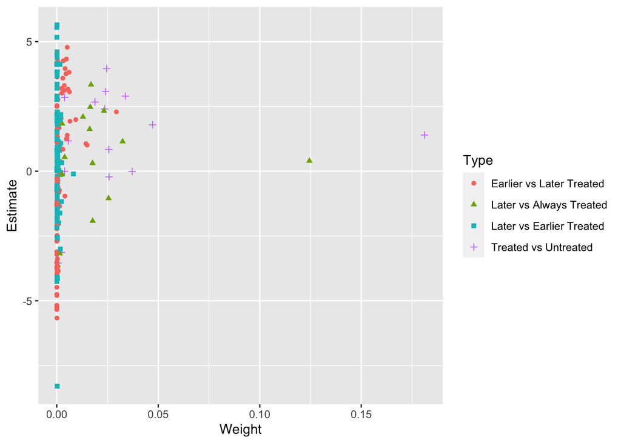

```r
ggplot(df_bacon) +
   aes(x = weight, y = estimate, shape = factor(type), color = factor(type)) +
   labs(x = "Weight", y = "Estimate", shape = "Type", color = 'Type') +
   geom_point()
```

```r
print(aggregate(df_bacon$estimate * df_bacon$weight, list(df_bacon$type), FUN=sum))
```

```
#>                    Group.1          x
#> 1 Earlier vs Later Treated 0.34817362
#> 2  Later vs Always Treated 0.23657303
#> 3 Later vs Earlier Treated 0.01670477
#> 4     Treated vs Untreated 0.73787343
```

The decomposition of the TWFE estimator in a staggered adoption setting by Goodman-Bacon (2021) shows that the estimates from the DIDs comparing ever-treated cohorts switching into treatment with the never-treated (purple crosses labeled “Treated vs Untreated”) contribute the most to the TWFE estimate. The DIDs comparing ever-treated cohorts switching into treatment and other ever-treated cohorts that are still in their pretreatment periods (the red dots labeled “Earlier vs Later Treated”) and the “forbidden” comparisons between ever-treated cohorts and the always-treated (green triangles labeled “Later vs Always Treated”) rank second and third in terms of their contribution. The “forbidden” DIDs comparing ever-treated cohorts switching into treatment and other ever-treated cohorts that are already treated (the blue squares labeled “Later vs Earlier Treated”) contribute the least to the TWFE estimate.

Additionally, to further address the issue of heterogeneous treatment effects across cohorts, we can use methods specifically designed to handle heterogeneous treatment effects, such as the methods outlined in Sun and Abraham (2021), Callaway and Sant’Anna (2021), and Liu, Wang, and Xu (2022). These methods can provide robust causal estimates that take into account the heterogeneous nature of treatment effects across different cohorts. By using these methods, we can better account for the potential bias introduced by the “forbidden” comparisons and obtain more accurate estimates of the treatment effects.

```r
# drop always treated units
df <- as.data.frame(data %>% group_by(bfs) %>% mutate(treatment_mean = mean(indirect,na.rm = TRUE)))
df.use <- df[which(df$treatment_mean<1),]

# Re-estimate TWFE on this Sub-sample
model.twfe.1 <- feols(nat_rate_ord~indirect|bfs+year,
                      data=df.use, cluster = "bfs")
print(model.twfe.1)
```

```
#> OLS estimation, Dep. Var.: nat_rate_ord
#> Observations: 17,594
#> Fixed-effects: bfs: 926,  year: 19
#> Standard-errors: Clustered (bfs)
#>          Estimate Std. Error t value  Pr(>|t|)
#> indirect  1.60858   0.195296 8.23661 6.009e-16 ***
#> ---
#> Signif. codes:  0 '***' 0.001 '**' 0.01 '*' 0.05 '.' 0.1 ' ' 1
#> RMSE: 4.43613     Adj. R2: 0.143692
#>                 Within R2: 0.007415
```

After removing the always-treated units, the estimated average treatment effect (ATT) increases to 1.609, with a standard error of 0.195. However, to fully address the bias caused by heterogeneous treatment effects (HTE), it is necessary to eliminate the “forbidden comparisons” through the use of HTE-robust estimators. Before implementing these estimators, we will demonstrate how to create an event study plot using a TWFE model with a dynamic specification.

## Event Study Plot for TWFE

In order to create an event study plot, we must first generate the cohort index and the relative time period for each observation in relation to treatment. These details are essential for various HTE-robust estimators, such as Sun and Abraham (2021) and Callaway and Sant’Anna (2021). We can use the function `get.cohort` in the package **paneltools** to generate these indices.

```r
df.use <- get.cohort(df.use,D="indirect",index=c("bfs","year"))
head(df.use[,-5],19)
```

```
#>    bfs year nat_rate_ord indirect FirstTreat      Cohort Time_to_Treatment
#> 1    1 1991     0.000000        0       2006 Cohort:2006               -15
#> 2    1 1992     0.000000        0       2006 Cohort:2006               -14
#> 3    1 1993     0.000000        0       2006 Cohort:2006               -13
#> 4    1 1994     3.448276        0       2006 Cohort:2006               -12
#> 5    1 1995     0.000000        0       2006 Cohort:2006               -11
#> 6    1 1996     0.000000        0       2006 Cohort:2006               -10
#> 7    1 1997     0.000000        0       2006 Cohort:2006                -9
#> 8    1 1998     0.000000        0       2006 Cohort:2006                -8
#> 9    1 1999     0.000000        0       2006 Cohort:2006                -7
#> 10   1 2000     0.000000        0       2006 Cohort:2006                -6
#> 11   1 2001     2.380952        0       2006 Cohort:2006                -5
#> 12   1 2002     0.000000        0       2006 Cohort:2006                -4
#> 13   1 2003     0.000000        0       2006 Cohort:2006                -3
#> 14   1 2004     0.000000        0       2006 Cohort:2006                -2
#> 15   1 2005     0.000000        0       2006 Cohort:2006                -1
#> 16   1 2006     1.612903        1       2006 Cohort:2006                 0
#> 17   1 2007    10.937500        1       2006 Cohort:2006                 1
#> 18   1 2008    14.285715        1       2006 Cohort:2006                 2
#> 19   1 2009     9.677419        1       2006 Cohort:2006                 3
```

The variable `FirstTreat` indicates the first period when a unit gets treated (for never-treated units, `FirstTreat` is set to `NA`), and the variable `Time_to_Treatment` indicates the relative period to the treatment’s onset (for always-treated and never-treated units, `Time_to_Treatment` is set to `NA`). The period `-1` corresponds to the last pre-treatment period.

We first use the dynamic TWFE regression, which is the workhorse model to estimate dynamic treatment effects in event studies, to create the event study plot. This model includes a series of interaction terms between a dummy that indicates whether a unit is a treated unit and each lead (lag) indicator relative to the treatment in a TWFE regression. This specification allows for effects to vary over time and usually uses the period immediately preceding a switch into the treatment as the reference period. If the regression is saturated and there is no heterogeneous treatment effects across cohorts, this dynamic TWFE can consistently estimate the dynamic treatment effect.

We still use the function `feols` to implement this estimator. The variable `Time_to_Treatment` can serve as the lead (lag) indicator (we need to replace the `NA` in `Time_to_Treatment` with an arbitrary number). Note that the period `-1` in `Time_to_Treatment` corresponds to the last pre-treatment period and is the reference period.

```r
# TWFE Dynamic
df.twfe <- df.use
df.twfe$treat <- as.numeric(df.twfe$treatment_mean>0) # drop always treated units
df.twfe[which(is.na(df.twfe$Time_to_Treatment)),'Time_to_Treatment'] <- 0 # can be an arbitrary value
twfe.est <- feols(nat_rate_ord ~ i(Time_to_Treatment, treat, ref = -1)| bfs + year,
                  data = df.twfe, cluster = "bfs")
twfe.output <- as.matrix(twfe.est$coeftable)
print(twfe.output)
```

```
#>                                 Estimate Std. Error    t value     Pr(>|t|)
#> Time_to_Treatment::-18:treat -0.32065076  0.6327017 -0.5067961 6.124187e-01
#> Time_to_Treatment::-17:treat -0.11854037  0.3911477 -0.3030578 7.619139e-01
#> Time_to_Treatment::-16:treat -0.39563213  0.4029210 -0.9819098 3.264010e-01
#> Time_to_Treatment::-15:treat -0.41097577  0.3438989 -1.1950482 2.323745e-01
#> Time_to_Treatment::-14:treat  0.24451225  0.3691273  0.6624062 5.078759e-01
#> Time_to_Treatment::-13:treat -0.04431012  0.3540169 -0.1251639 9.004210e-01
#> Time_to_Treatment::-12:treat -0.54589060  0.3151718 -1.7320415 8.359954e-02
#> Time_to_Treatment::-11:treat -0.29313843  0.3468354 -0.8451804 3.982287e-01
#> Time_to_Treatment::-10:treat -0.42398107  0.3193748 -1.3275344 1.846595e-01
#> Time_to_Treatment::-9:treat  -0.46711352  0.3010171 -1.5517839 1.210560e-01
#> Time_to_Treatment::-8:treat  -0.11563334  0.3336591 -0.3465614 7.289997e-01
#> Time_to_Treatment::-7:treat  -0.72428992  0.3057269 -2.3690752 1.803716e-02
#> Time_to_Treatment::-6:treat  -0.57295020  0.3171533 -1.8065400 7.115891e-02
#> Time_to_Treatment::-5:treat  -0.55499321  0.3092458 -1.7946670 7.303318e-02
#> Time_to_Treatment::-4:treat   0.06620907  0.3451034  0.1918529 8.478996e-01
#> Time_to_Treatment::-3:treat  -0.50953012  0.3162958 -1.6109292 1.075363e-01
#> Time_to_Treatment::-2:treat  -0.19509150  0.3302199 -0.5907926 5.548037e-01
#> Time_to_Treatment::0:treat    0.52271487  0.3596460  1.4534151 1.464477e-01
#> Time_to_Treatment::1:treat    1.66883434  0.3679186  4.5358788 6.490737e-06
#> Time_to_Treatment::2:treat    1.72423014  0.4713628  3.6579681 2.685814e-04
#> Time_to_Treatment::3:treat    1.17833624  0.4005586  2.9417322 3.345229e-03
#> Time_to_Treatment::4:treat    0.75632268  0.4786966  1.5799624 1.144573e-01
#> Time_to_Treatment::5:treat    2.43822935  0.7054512  3.4562694 5.726291e-04
#> Time_to_Treatment::6:treat    2.84859038  0.8053149  3.5372380 4.244244e-04
#> Time_to_Treatment::7:treat    2.40935895  0.7837161  3.0742752 2.172064e-03
#> Time_to_Treatment::8:treat    2.27042846  0.7978687  2.8456167 4.530459e-03
#> Time_to_Treatment::9:treat    2.39267761  0.8632219  2.7717990 5.686658e-03
#> Time_to_Treatment::10:treat   2.00283605  0.9536545  2.1001695 3.598421e-02
#> Time_to_Treatment::11:treat   0.84259034  0.5602476  1.5039607 1.329328e-01
#> Time_to_Treatment::12:treat   3.83191775  2.3004225  1.6657452 9.610276e-02
#> Time_to_Treatment::13:treat   4.43643668  2.3223177  1.9103487 5.639730e-02
#> Time_to_Treatment::14:treat   4.75697725  3.4855231  1.3647814 1.726536e-01
#> Time_to_Treatment::15:treat   1.54196720  1.4152835  1.0895112 2.762123e-01
#> Time_to_Treatment::16:treat   7.16894343  4.8440161  1.4799586 1.392248e-01
#> Time_to_Treatment::17:treat   6.49085407  2.7265262  2.3806315 1.748463e-02
#> attr(,"type")
#> [1] "Clustered (bfs)"
```

The **paneltools** package offers a useful function, `esplot()`, that can be utilized to effectively visualize results. In this instance, we utilize the function to examine the dynamic effects over a 13 period pre-treatment span and a 10 period post-treatment span. The data reveals a significant impact of the treatment, as well as a subtle pre-trend discrepancy in a number of periods preceding the treatment. It is important to note that `esplot()` considers period 0 to be the final pre-treatment period, so it is necessary to shift the period index by one unit.

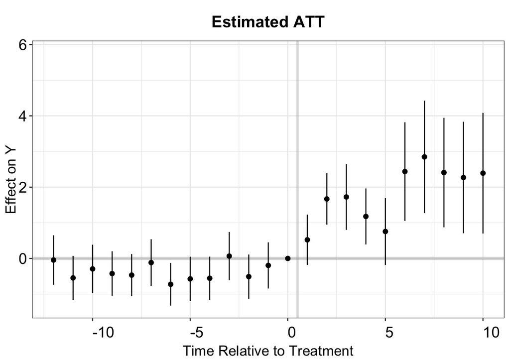

```r
twfe.output <- as.data.frame(twfe.output)
twfe.output$Time <- c(c(-18:-2),c(0:17))+1 #
p.twfe <- esplot(twfe.output,Period = 'Time',Estimate = 'Estimate',
                               SE = 'Std. Error', xlim = c(-12,10))
p.twfe
```

## Stacked DID

The study, Cengiz et al. (2019), examines the effect of variations in minimum wage on low-wage employment across 138 state-level minimum wage changes in the United States between 1979 and 2016, utilizing a stacked difference-in-differences (DID) approach. A similar estimator is also implemented in the Stata package STACKEDEV, as per Bleiberg (2021). This stacked DID method eliminates the bias resulted from “forbidden” comparisons in the Goodman-Bacon decomposition. However, it still relies on the implicit weights chosen by OLS, making it less robust in terms of heterogeneous treatment effects (HTE) and less interpretable compared to other HTE-robust estimators.

The study employs a stacked difference-in-differences approach to estimate the impact of minimum wage changes on low-wage jobs across a series of 138 state-level minimum wage changes between 1979 and 2016 in the United States. For each ever-treated cohort, a cohort-specific dataset is created, comprising of the cohort and all never-treated units. These cohort-specific datasets are then stacked in order to calculate an average effect across all cohorts by utilizing fixed effects regression, while controlling for stack-unit interaction fixed effects and stack-year interaction fixed effects. With this stacked cohort-specific dataset, dynamic treatment effects can be obtained in a similar way as with the TWFE estimator.

```r
df.st <- NULL
target.cohorts <- setdiff(unique(df.use$Cohort),"Control")
k <- 1
for(cohort in target.cohorts){
  df.sub <- df.use[which(df.use$Cohort%in%c(cohort,"Control")),]
  df.sub$stack <- k
  df.st <- rbind(df.st,df.sub)
  k <- k + 1
}
df.st$st_unit <- as.numeric(factor(paste0(df.st$stack,'-',df.st$bfs)))
df.st$st_year <- as.numeric(factor(paste0(df.st$stack,'-',df.st$year)))
model.st <- feols(nat_rate_ord~indirect|st_unit+st_year,
                  data=df.st, cluster = "st_unit")
print(model.st)
```

```
#> OLS estimation, Dep. Var.: nat_rate_ord
#> Observations: 127,186
#> Fixed-effects: st_unit: 6,694,  st_year: 285
#> Standard-errors: Clustered (st_unit)
#>          Estimate Std. Error t value  Pr(>|t|)
#> indirect  1.66861    0.18237 9.14958 < 2.2e-16 ***
#> ---
#> Signif. codes:  0 '***' 0.001 '**' 0.01 '*' 0.05 '.' 0.1 ' ' 1
#> RMSE: 3.9095     Adj. R2: 0.130512
#>                Within R2: 0.001783
```

### Event Study Plot

```r
df.st$treat <- as.numeric(df.st$treatment_mean>0)
df.st[which(is.na(df.st$Time_to_Treatment)),'Time_to_Treatment'] <- 0 # can be arbitrary value
st.est <- feols(nat_rate_ord ~ i(Time_to_Treatment, treat, ref = -1)| st_unit + st_year,data = df.st,cluster = "st_unit")
print(st.est$coeftable)
```

```
#>                                 Estimate Std. Error     t value     Pr(>|t|)
#> Time_to_Treatment::-18:treat -0.32876531  0.6246666 -0.52630524 5.986936e-01
#> Time_to_Treatment::-17:treat -0.08402861  0.3726755 -0.22547391 8.216175e-01
#> Time_to_Treatment::-16:treat -0.23704732  0.3890202 -0.60934446 5.423168e-01
#> Time_to_Treatment::-15:treat -0.33039222  0.3358986 -0.98360689 3.253444e-01
#> Time_to_Treatment::-14:treat  0.21942491  0.3595513  0.61027425 5.417009e-01
#> Time_to_Treatment::-13:treat -0.13145445  0.3443222 -0.38177744 7.026386e-01
#> Time_to_Treatment::-12:treat -0.58822817  0.3113593 -1.88922655 5.890467e-02
#> Time_to_Treatment::-11:treat -0.26344604  0.3437730 -0.76633722 4.435027e-01
#> Time_to_Treatment::-10:treat -0.54375457  0.3218685 -1.68936845 9.119542e-02
#> Time_to_Treatment::-9:treat  -0.56120024  0.3065223 -1.83086265 6.716548e-02
#> Time_to_Treatment::-8:treat  -0.09265692  0.3389478 -0.27336634 7.845801e-01
#> Time_to_Treatment::-7:treat  -0.58880594  0.3070364 -1.91770753 5.519062e-02
#> Time_to_Treatment::-6:treat  -0.47516514  0.3257192 -1.45881816 1.446621e-01
#> Time_to_Treatment::-5:treat  -0.39993315  0.3112587 -1.28488986 1.988752e-01
#> Time_to_Treatment::-4:treat   0.23387391  0.3587515  0.65191065 5.144812e-01
#> Time_to_Treatment::-3:treat  -0.24046110  0.3308839 -0.72672341 4.674208e-01
#> Time_to_Treatment::-2:treat  -0.01674545  0.3466380 -0.04830817 9.614721e-01
#> Time_to_Treatment::0:treat    0.63988908  0.3639778  1.75804440 7.878566e-02
#> Time_to_Treatment::1:treat    1.63436478  0.3698039  4.41954479 1.004695e-05
#> Time_to_Treatment::2:treat    1.78039699  0.4911171  3.62519828 2.908847e-04
#> Time_to_Treatment::3:treat    1.10329058  0.4123146  2.67584672 7.472221e-03
#> Time_to_Treatment::4:treat    0.85952703  0.4895732  1.75566599 7.919120e-02
#> Time_to_Treatment::5:treat    2.44794424  0.7113218  3.44140212 5.822459e-04
#> Time_to_Treatment::6:treat    2.80029784  0.8125259  3.44641044 5.715789e-04
#> Time_to_Treatment::7:treat    2.29340055  0.7978800  2.87436774 4.061131e-03
#> Time_to_Treatment::8:treat    2.38558084  0.7977891  2.99023997 2.797728e-03
#> Time_to_Treatment::9:treat    2.20907842  0.8509387  2.59604885 9.450873e-03
#> Time_to_Treatment::10:treat   1.90401019  0.9458353  2.01304633 4.414972e-02
#> Time_to_Treatment::11:treat   0.51499900  0.5518266  0.93326236 3.507182e-01
#> Time_to_Treatment::12:treat   3.95439028  2.2940011  1.72379617 8.479083e-02
#> Time_to_Treatment::13:treat   4.39078917  2.3089816  1.90161286 5.726468e-02
#> Time_to_Treatment::14:treat   4.61626419  3.4608264  1.33386181 1.822945e-01
#> Time_to_Treatment::15:treat   1.18977420  1.3883525  0.85696841 3.914930e-01
#> Time_to_Treatment::16:treat   6.75219353  4.8161984  1.40197579 1.609689e-01
#> Time_to_Treatment::17:treat   5.95993087  2.7217298  2.18975843 2.857616e-02
#> attr(,"type")
#> [1] "Clustered (st_unit)"
```

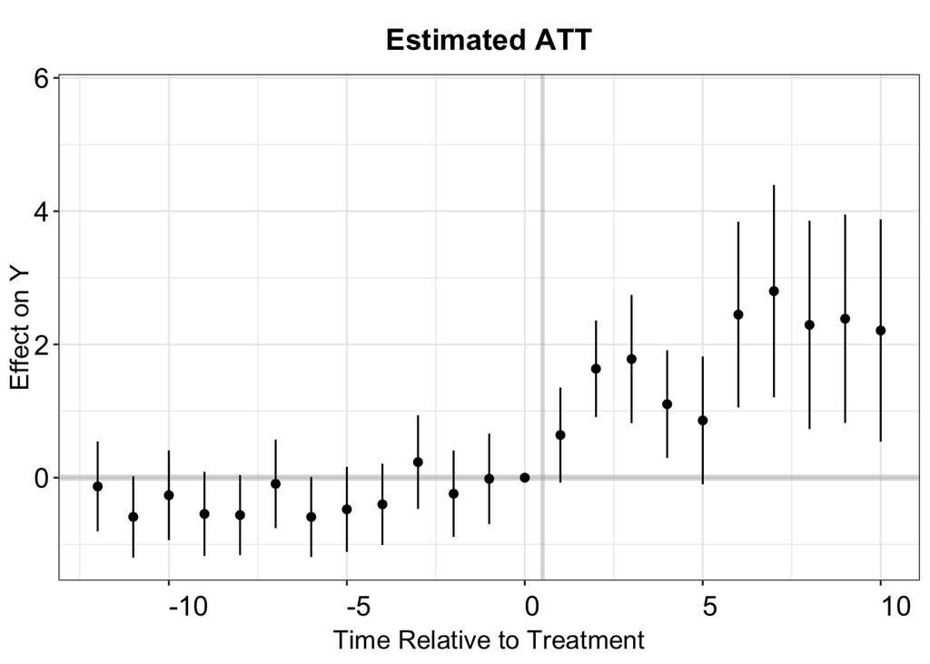

```r
st.output <- as.data.frame(st.est$coeftable)
st.output$Time <- c(c(-18:-2),c(0:17))+1 #
p.st <- esplot(st.output,Period = 'Time',Estimate = 'Estimate',
                               SE = 'Std. Error', xlim = c(-12,10))
p.st
```

## Interaction Weighted

In the study Sun and Abraham (2021), an interaction-weighted (iw) estimator is proposed as a means of estimating heterogeneous treatment effects. This estimator is a weighted average of the average treatment effect (ATT) estimates for each cohort, obtained from a TWFE regression that includes cohort dummies fully interacted with indicators of relative time to the treatment’s onset. The iw estimator is robust to heterogeneous treatment effects (HTE) and can be implemented using the command `sunab` in the package **fixest**. The variable `FirstTreat` serves as the cohort indicator, and any missing values in this variable should be replaced with an arbitrary number. The estimated ATT obtained using the iw estimator is 1.331, with a standard error of 0.288.

```r
df.sa <- df.use
df.sa[which(is.na(df.sa$FirstTreat)),"FirstTreat"] <- 1000 # replace NA with an arbitrary number
model.sa.1 <- feols(nat_rate_ord~sunab(FirstTreat,year)|bfs+year,
                    data = df.sa, cluster = "bfs")
summary(model.sa.1,agg = "ATT")
```

```
#> OLS estimation, Dep. Var.: nat_rate_ord
#> Observations: 17,594
#> Fixed-effects: bfs: 926,  year: 19
#> Standard-errors: Clustered (bfs)
#>     Estimate Std. Error t value   Pr(>|t|)
#> ATT   1.3309   0.287971 4.62163 4.3474e-06 ***
#> ---
#> Signif. codes:  0 '***' 0.001 '**' 0.01 '*' 0.05 '.' 0.1 ' ' 1
#> RMSE: 4.34795     Adj. R2: 0.163888
#>                 Within R2: 0.046484
```

### Event Study Plot

The results of this estimation are saved in the object `coeftable` for further analysis.

```r
sa.output <- as.matrix(model.sa.1$coeftable)
print(sa.output)
```

```
#>              Estimate Std. Error     t value     Pr(>|t|)
#> year::-18 -0.26588766  0.7883091 -0.33728860 7.359759e-01
#> year::-17  0.17803769  0.5029562  0.35398250 7.234327e-01
#> year::-16  0.11405908  0.5185987  0.21993705 8.259687e-01
#> year::-15 -0.10395137  0.4074327 -0.25513753 7.986736e-01
#> year::-14  0.41028405  0.4131183  0.99313944 3.209017e-01
#> year::-13  0.09073535  0.3972375  0.22841588 8.193734e-01
#> year::-12 -0.56191688  0.3689700 -1.52293385 1.281170e-01
#> year::-11 -0.32332911  0.3836954 -0.84267130 3.996301e-01
#> year::-10 -0.50966995  0.3531793 -1.44309135 1.493333e-01
#> year::-9  -0.46891460  0.3436058 -1.36468774 1.726831e-01
#> year::-8   0.06132399  0.3645946  0.16819776 8.664645e-01
#> year::-7  -0.50027176  0.3084227 -1.62203273 1.051371e-01
#> year::-6  -0.39220920  0.3289499 -1.19230663 2.334468e-01
#> year::-5  -0.22991949  0.3217699 -0.71454628 4.750697e-01
#> year::-4   0.41857502  0.3512752  1.19158713 2.337288e-01
#> year::-3  -0.19712944  0.3199730 -0.61608158 5.379922e-01
#> year::-2  -0.02786173  0.3420857 -0.08144663 9.351044e-01
#> year::0    0.71412228  0.3755381  1.90159764 5.753426e-02
#> year::1    1.58464318  0.3615507  4.38290760 1.305219e-05
#> year::2    1.63374738  0.5093517  3.20750354 1.384925e-03
#> year::3    0.90899520  0.4276159  2.12572845 3.379026e-02
#> year::4    0.40908313  0.5464691  0.74859332 4.542927e-01
#> year::5    2.11063582  0.7741950  2.72623267 6.527297e-03
#> year::6    2.48424347  0.8628637  2.87906816 4.080461e-03
#> year::7    2.38015298  0.7861370  3.02765689 2.532923e-03
#> year::8    2.56023855  0.8504950  3.01029215 2.680822e-03
#> year::9    2.00995330  0.9579247  2.09823736 3.615491e-02
#> year::10   1.63910238  0.9721952  1.68598068 9.213676e-02
#> year::11   0.02976808  0.5346014  0.05568277 9.556066e-01
#> year::12   0.69417518  2.7317900  0.25411001 7.994670e-01
#> year::13   1.13548295  1.9972762  0.56851575 5.698228e-01
#> year::14   1.36246531  3.1273735  0.43565801 6.631865e-01
#> year::15  -2.06989292  1.4381238 -1.43930094 1.504036e-01
#> year::16   2.27432076  3.0784404  0.73878992 4.602220e-01
#> year::17   0.10722911  4.5738694  0.02344385 9.813013e-01
#> attr(,"type")
#> [1] "Clustered (bfs)"
```

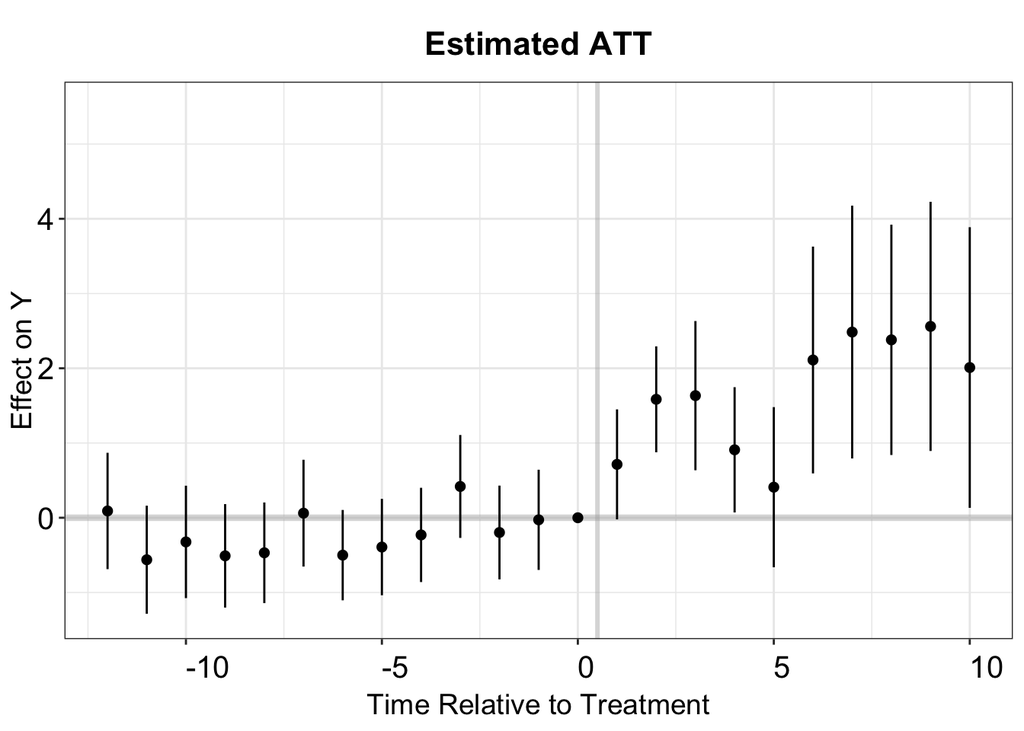

```r
sa.output <- as.data.frame(sa.output)
sa.output$Time <- c(c(-18:-2),c(0:17))+1
p.sa <- esplot(sa.output,Period = 'Time',Estimate = 'Estimate',
                             SE = 'Std. Error', xlim = c(-12,10))
p.sa
```

## CSDID

Callaway and Sant’Anna (2021) proposed a doubly-robust estimator, referred to as csdid, that incorporates pre-treatment covariates by using either never-treated or not-yet-treated units as the comparison group. In this tutorial, we will only be utilizing the outcome model instead of the double-robust model to calculate the ATT and dynamic treatment effects.

First, we use the never-treated units as the comparison group. The variable `FirstTreat` serves as the cohort indicator, where we replace the missing values in `FirstTreat` with 0. The estimated ATT is numerically the same as the iw estimator. Additionally, we set the option `bstrap` to `FALSE` in order to report the analytical standard error, which is 0.302.

```r
df.cs <- df.use
df.cs[which(is.na(df.cs$FirstTreat)),"FirstTreat"] <- 0 # replace NA with 0
cs.est.1 <- att_gt(yname = "nat_rate_ord",
                 gname = "FirstTreat",
                 idname = "bfs",
                 tname = "year",
                 xformla = ~1,
                 control_group = "nevertreated",
                 allow_unbalanced_panel = TRUE,
                 data = df.cs,
                 est_method = "reg")
cs.est.att.1 <- aggte(cs.est.1, type = "simple", na.rm=T, bstrap = F)
print(cs.est.att.1)
```

```
#>
#> Call:
#> aggte(MP = cs.est.1, type = "simple", na.rm = T, bstrap = F)
#>
#> Reference: Callaway, Brantly and Pedro H.C. Sant'Anna.  "Difference-in-Differences with Multiple Time Periods." Journal of Econometrics, Vol. 225, No. 2, pp. 200-230, 2021. <https://doi.org/10.1016/j.jeconom.2020.12.001>, <https://arxiv.org/abs/1803.09015>
#>
#>
#>     ATT    Std. Error     [ 95%  Conf. Int.]
#>  1.3309        0.3019     0.7392      1.9226 *
#>
#>
#> ---
#> Signif. codes: `*' confidence band does not cover 0
#>
#> Control Group:  Never Treated,  Anticipation Periods:  0
#> Estimation Method:  Outcome Regression
```

### Event Study Plot

The csdid estimator utilizes the command `aggte` to aggregate the cohort-period average treatment effects. We set the option `bstrap` to `FALSE` to report analytical standard errors and the option `cband` to `FALSE` to report period-wise confidence intervals. This allows for easy comparison with other estimators. Note that the `aggte` command also has the capability to compute uniform confidence bands by setting `cband` and `bstrap` to `TRUE`, but in this case we chose to report period-wise intervals.

```r
cs.att.1 <- aggte(cs.est.1, type = "dynamic",
                  bstrap=FALSE, cband=FALSE, na.rm=T)
print(cs.att.1)
```

```
#>
#> Call:
#> aggte(MP = cs.est.1, type = "dynamic", na.rm = T, bstrap = FALSE,
#>     cband = FALSE)
#>
#> Reference: Callaway, Brantly and Pedro H.C. Sant'Anna.  "Difference-in-Differences with Multiple Time Periods." Journal of Econometrics, Vol. 225, No. 2, pp. 200-230, 2021. <https://doi.org/10.1016/j.jeconom.2020.12.001>, <https://arxiv.org/abs/1803.09015>
#>
#>
#> Overall summary of ATT's based on event-study/dynamic aggregation:
#>     ATT    Std. Error     [ 95%  Conf. Int.]
#>  1.2205        0.6314    -0.0171       2.458
#>
#>
#> Dynamic Effects:
#>  Event time Estimate Std. Error [95% Pointwise  Conf. Band]
#>         -17   0.1350     0.6467         -1.1324      1.4025
#>         -16  -0.0839     0.3583         -0.7861      0.6183
#>         -15   0.1467     0.3964         -0.6303      0.9236
#>         -14   0.7509     0.3219          0.1200      1.3818 *
#>         -13  -0.2318     0.3392         -0.8967      0.4331
#>         -12  -0.5851     0.2814         -1.1367     -0.0335 *
#>         -11   0.2656     0.2705         -0.2647      0.7958
#>         -10  -0.2386     0.2805         -0.7883      0.3111
#>          -9   0.0576     0.2702         -0.4721      0.5872
#>          -8   0.5244     0.3165         -0.0959      1.1448
#>          -7  -0.6282     0.3132         -1.2420     -0.0144 *
#>          -6   0.1081     0.2565         -0.3946      0.6108
#>          -5   0.1623     0.2890         -0.4041      0.7287
#>          -4   0.6485     0.3380         -0.0139      1.3109
#>          -3  -0.6161     0.3674         -1.3362      0.1040
#>          -2   0.1505     0.3355         -0.5071      0.8081
#>          -1   0.0279     0.3425         -0.6435      0.6992
#>           0   0.7141     0.3754         -0.0217      1.4500
#>           1   1.5846     0.3681          0.8632      2.3060 *
#>           2   1.6337     0.5118          0.6306      2.6369 *
#>           3   0.9090     0.4396          0.0473      1.7707 *
#>           4   0.4091     0.5725         -0.7130      1.5311
#>           5   2.1106     0.7976          0.5473      3.6739 *
#>           6   2.4842     0.9078          0.7051      4.2634 *
#>           7   2.3802     0.8538          0.7068      4.0535 *
#>           8   2.5602     0.8723          0.8506      4.2699 *
#>           9   2.0100     0.9769          0.0953      3.9246 *
#>          10   1.6391     1.0257         -0.3712      3.6494
#>          11   0.0298     0.6100         -1.1658      1.2253
#>          12   0.6942     2.8043         -4.8021      6.1904
#>          13   1.1355     2.3284         -3.4281      5.6991
#>          14   1.3625     3.4131         -5.3270      8.0519
#>          15  -2.0699     1.7160         -5.4331      1.2933
#>          16   2.2743     3.6182         -4.8172      9.3658
#>          17   0.1072     4.5338         -8.7789      8.9934
#> ---
#> Signif. codes: `*' confidence band does not cover 0
#>
#> Control Group:  Never Treated,  Anticipation Periods:  0
#> Estimation Method:  Outcome Regression
```

The estimated dynamic treatment effects during the post-treatment period are numerically the same as those obtained from the iw estimator. However, the estimates for the pre-treatment period may differ as the csdid estimator does not rely on a single reference period. We present the results in a similar manner and it can be observed that there is a significant treatment effect present, with no clear pre-trend difference.

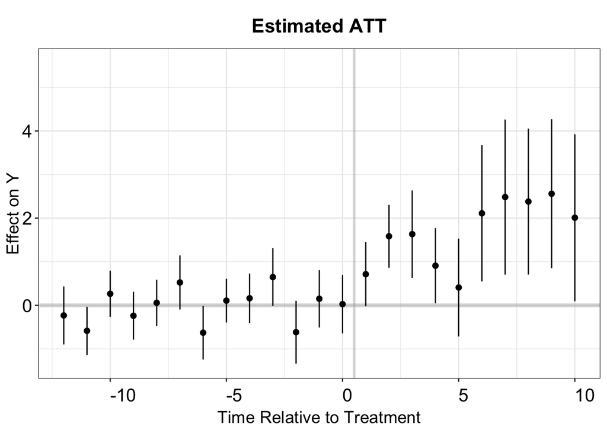

```r
cs.output <- cbind.data.frame(Estimate = cs.att.1$att.egt,
                              SE = cs.att.1$se.egt,
                              time = cs.att.1$egt + 1)
p.cs.1 <- esplot(cs.output,Period = 'time',Estimate = 'Estimate',
                               SE = 'SE', xlim = c(-12,10))
p.cs.1
```

We can also use the **not-yet-treated** units as the comparison group by setting `control_group = "notyettreated"`. The choice of the comparison group depends on the specific version of the parallel trend assumption that researchers need to justify. The estimated ATT is 1.292, with a standard error of 0.308.

```r
cs.est.2 <- att_gt(yname = "nat_rate_ord",
                   gname = "FirstTreat",
                   idname = "bfs",
                   tname = "year",
                   xformla = ~1,
                   control_group = "notyettreated",
                   allow_unbalanced_panel = TRUE,
                   data = df.cs,
                   est_method = "reg")
cs.est.att.2 <- aggte(cs.est.2, type = "simple",na.rm=T, bstrap = F)
print(cs.est.att.2)
```

```
#>
#> Call:
#> aggte(MP = cs.est.2, type = "simple", na.rm = T, bstrap = F)
#>
#> Reference: Callaway, Brantly and Pedro H.C. Sant'Anna.  "Difference-in-Differences with Multiple Time Periods." Journal of Econometrics, Vol. 225, No. 2, pp. 200-230, 2021. <https://doi.org/10.1016/j.jeconom.2020.12.001>, <https://arxiv.org/abs/1803.09015>
#>
#>
#>     ATT    Std. Error     [ 95%  Conf. Int.]
#>  1.2923         0.308     0.6886       1.896 *
#>
#>
#> ---
#> Signif. codes: `*' confidence band does not cover 0
#>
#> Control Group:  Not Yet Treated,  Anticipation Periods:  0
#> Estimation Method:  Outcome Regression
```

We can calculate the dynamic treatment effects using the same method.

```r
cs.att.2 <- aggte(cs.est.2, type = "dynamic",
                  bstrap=FALSE,cband=FALSE,na.rm=T)
print(cs.att.2)
```

```
#>
#> Call:
#> aggte(MP = cs.est.2, type = "dynamic", na.rm = T, bstrap = FALSE,
#>     cband = FALSE)
#>
#> Reference: Callaway, Brantly and Pedro H.C. Sant'Anna.  "Difference-in-Differences with Multiple Time Periods." Journal of Econometrics, Vol. 225, No. 2, pp. 200-230, 2021. <https://doi.org/10.1016/j.jeconom.2020.12.001>, <https://arxiv.org/abs/1803.09015>
#>
#>
#> Overall summary of ATT's based on event-study/dynamic aggregation:
#>     ATT    Std. Error     [ 95%  Conf. Int.]
#>  1.2359        0.6337    -0.0062       2.478
#>
#>
#> Dynamic Effects:
#>  Event time Estimate Std. Error [95% Pointwise  Conf. Band]
#>         -17  -0.0629     0.6363         -1.3100      1.1841
#>         -16  -0.2656     0.3626         -0.9763      0.4452
#>         -15   0.2242     0.4072         -0.5738      1.0222
#>         -14   0.8526     0.3273          0.2111      1.4940 *
#>         -13  -0.2011     0.3436         -0.8746      0.4724
#>         -12  -0.6488     0.2829         -1.2033     -0.0943 *
#>         -11   0.1963     0.2735         -0.3396      0.7323
#>         -10  -0.0609     0.2733         -0.5966      0.4748
#>          -9   0.0233     0.2663         -0.4985      0.5452
#>          -8   0.3539     0.3225         -0.2781      0.9859
#>          -7  -0.7367     0.3253         -1.3743     -0.0992 *
#>          -6   0.1658     0.2615         -0.3468      0.6784
#>          -5   0.0376     0.3036         -0.5574      0.6325
#>          -4   0.7782     0.3527          0.0869      1.4695 *
#>          -3  -0.7900     0.3849         -1.5444     -0.0356 *
#>          -2   0.3214     0.3423         -0.3495      0.9923
#>          -1   0.0906     0.3386         -0.5731      0.7543
#>           0   0.5757     0.3835         -0.1761      1.3274
#>           1   1.5347     0.3755          0.7986      2.2707 *
#>           2   1.5818     0.5134          0.5756      2.5880 *
#>           3   0.8832     0.4451          0.0108      1.7556 *
#>           4   0.3647     0.5792         -0.7705      1.5000
#>           5   2.1045     0.8005          0.5355      3.6734 *
#>           6   2.6091     0.9054          0.8346      4.3836 *
#>           7   2.4869     0.8481          0.8247      4.1492 *
#>           8   2.5860     0.8725          0.8759      4.2961 *
#>           9   2.1076     0.9814          0.1841      4.0311 *
#>          10   1.5353     1.0223         -0.4683      3.5389
#>          11   0.0751     0.6043         -1.1094      1.2596
#>          12   0.8129     2.8107         -4.6960      6.3218
#>          13   1.2552     2.3333         -3.3181      5.8284
#>          14   1.4144     3.4089         -5.2670      8.0958
#>          15  -2.0470     1.7125         -5.4034      1.3094
#>          16   2.2586     3.6230         -4.8425      9.3596
#>          17   0.1072     4.5338         -8.7789      8.9934
#> ---
#> Signif. codes: `*' confidence band does not cover 0
#>
#> Control Group:  Not Yet Treated,  Anticipation Periods:  0
#> Estimation Method:  Outcome Regression
```

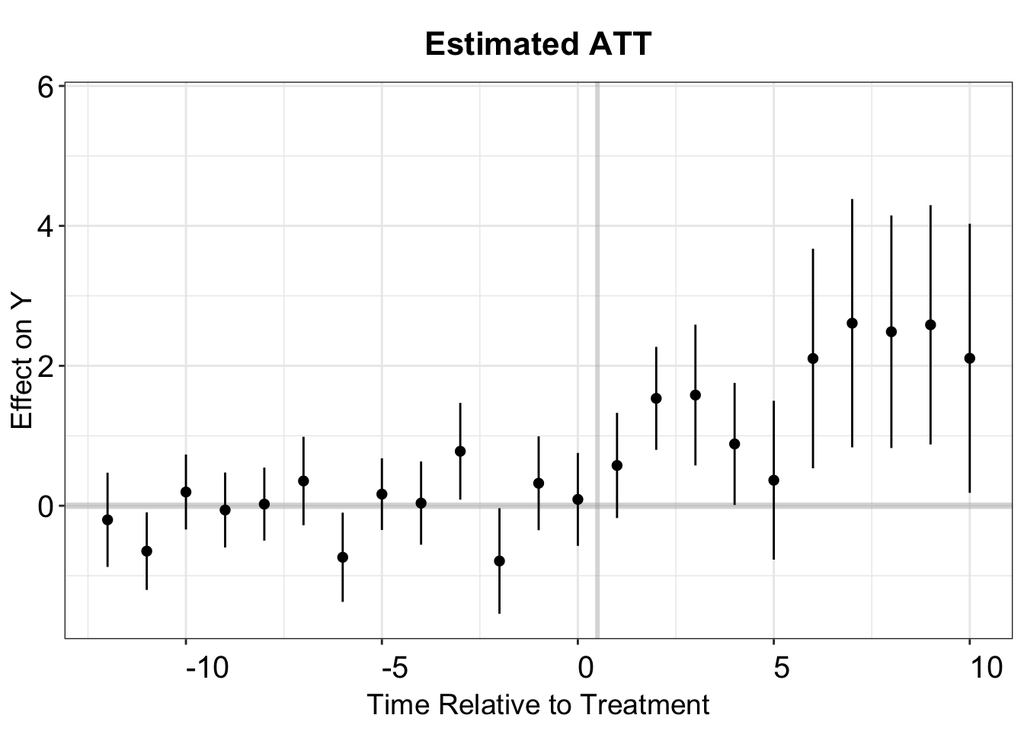

```r
cs.output <- cbind.data.frame(Estimate = cs.att.2$att.egt,
                              SE = cs.att.2$se.egt,
                              time = cs.att.2$egt + 1)
p.cs.2 <- esplot(cs.output,Period = 'time',Estimate = 'Estimate',
                               SE = 'SE', xlim = c(-12,10))
p.cs.2
```

## PanelMatch

In Imai, Kim, and Wang (2021), a matching framework is proposed as a generalization of the difference-in-differences estimator. This framework allows researchers to match each treated observation for a given unit in a particular period with untreated observations from other units in the same period that have similar treatment, outcome, or covariate histories.

The `PanelMatch` command can be utilized to create these matched sets. The option `lag = 3` indicates that the pre-treatment history periods to be matched on should have a length of 3, while the option `lead = c(0:3)` specifies that the lead window should be four post-treatment periods. To assign equal weights to all control units in each matched set, the option `refinement.method="none"` is set. It is important to note that by matching on treatment history and specifying the lead window, the `PanelMatch` command only uses a subset of treated units that have 3 pre-treatment periods and 4 post-treatment periods to compute the average treatment effects.

The PanelMatch estimator is also equivalent to the $DID_{M}$ estimator proposed by Chaisemartin and D’Haultfœuille (2020) if we only match on the last pre-treatment period and only estimate the treatment effect at the first post-treatment period.

```r
df.pm <- df.use
# we need to convert the unit and time indicator to integer
df.pm[,"bfs"] <- as.integer(as.factor(df.pm[,"bfs"]))
df.pm[,"year"] <- as.integer(as.factor(df.pm[,"year"]))
df.pm <- df.pm[,c("bfs","year","nat_rate_ord","indirect")]

PM.results <- PanelMatch(lag=3,
                         time.id="year",
                         unit.id = "bfs",
                         treatment = 'indirect',
                         refinement.method = "none",
                         data = df.pm,
                         qoi = "att",
                         lead = c(0:3),
                         outcome.var = 'nat_rate_ord',
                         match.missing = TRUE)

## For pre-treatment dynamic effects
PM.results.placebo <- PanelMatch(lag=3,
                         time.id="year",
                         unit.id = "bfs",
                         treatment = 'indirect',
                         refinement.method = "none",
                         data = df.pm,
                         qoi = "att",
                         lead = c(0:3),
                         outcome.var = 'nat_rate_ord',
                         match.missing = TRUE,
                         placebo.test = TRUE)
```

We can estimate the ATT and dynamic treatment effects using the command `PanelEstimate`. To obtain the ATT, we set the option `pooled = TRUE`. The standard error is calculated using a block bootstrapping method.

```r
# ATT
PE.results.pool <- PanelEstimate(PM.results, data = df.pm, pooled = TRUE)
summary(PE.results.pool)
```

```
#> Matches created with 3 lags
#>
#> Standard errors computed with 1000 Weighted bootstrap samples
#>
#> Estimate of Average Treatment Effect on the Treated (ATT) by Period:
#> $summary
#>      estimate std.error      2.5%    97.5%
#> [1,] 1.177674 0.3632403 0.4308786 1.862727
#>
#> $lag
#> [1] 3
#>
#> $iterations
#> [1] 1000
#>
#> $qoi
#> [1] "att"
```

### Event Study Plot

We can also use the command PanelEstimate to estimate the dynamic treatment effects at post-treatment periods. Additionally, for pre-treatment periods, PanelMatch offers the command `placebo_test` to compute the change in outcomes for each pre-treatment period in the lag window compared to the last pre-treatment period.

```r
# Dynamic Treatment Effects
PE.results <- PanelEstimate(PM.results, data = df.pm)
PE.results.placebo <- placebo_test(PM.results.placebo, data = df.pm, plot = F)
```

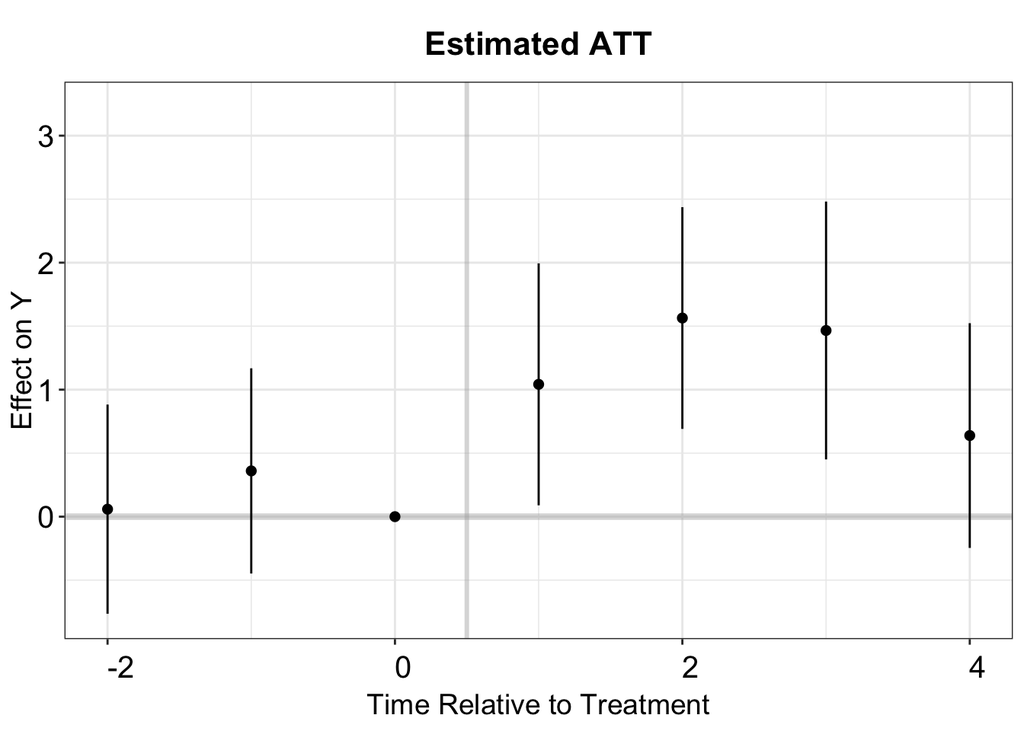

```r
est_lead <- as.vector(PE.results$estimates)
est_lag <- as.vector(PE.results.placebo$estimates)
sd_lead <- apply(PE.results$bootstrapped.estimates,2,sd)
sd_lag <- apply(PE.results.placebo$bootstrapped.estimates,2,sd)
coef <- c(est_lag, 0, est_lead)
sd <- c(sd_lag, 0, sd_lead)
pm.output <- cbind.data.frame(ATT=coef, se=sd, t=c(-2:4))
p.pm <- esplot(data = pm.output,Period = 't',
               Estimate = 'ATT',SE = 'se')
p.pm
```

## Imputation Method

```r
out.fect <- fect(nat_rate_ord~indirect, data = df, index = c("bfs","year"),
                 method = 'fe', se = TRUE)
print(out.fect$est.avg)
```

```
#>       ATT.avg      S.E. CI.lower CI.upper      p.value
#> [1,] 1.506416 0.2052678 1.104099 1.908734 2.156053e-13
```

The fect function stores the estimated dynamic treatment effects that are obtained using the counterfactual method in the object `est.att`. The uncertainty estimates for these estimates are obtained through a nonparametric clustered bootstrap procedure.

```r
fect.output <- as.matrix(out.fect$est.att)
print(fect.output)
```

```
#>             ATT      S.E.     CI.lower     CI.upper      p.value count
#> -17 -0.01985591 0.4878539 -0.976032054  0.936320242 9.675347e-01    89
#> -16  0.07269638 0.2096894 -0.338287228  0.483679982 7.288272e-01   157
#> -15 -0.21365489 0.2657927 -0.734599085  0.307289307 4.214893e-01   162
#> -14 -0.13153052 0.1707489 -0.466192133  0.203131099 4.411127e-01   350
#> -13  0.46902947 0.2230022  0.031953159  0.906105787 3.544390e-02   371
#> -12  0.24357664 0.1944239 -0.137487287  0.624640573 2.102741e-01   398
#> -11 -0.24399485 0.1217989 -0.482716314 -0.005273378 4.514941e-02   417
#> -10 -0.02765866 0.1773139 -0.375187452  0.319870132 8.760433e-01   434
#> -9  -0.09347047 0.1368538 -0.361698965  0.174758024 4.946099e-01   451
#> -8  -0.10638473 0.1493041 -0.399015371  0.186245919 4.761322e-01   464
#> -7   0.17476094 0.1930326 -0.203575925  0.553097806 3.652830e-01   468
#> -6  -0.40297604 0.1577457 -0.712151985 -0.093800092 1.063122e-02   503
#> -5  -0.24326436 0.1736601 -0.583631917  0.097103206 1.612717e-01   503
#> -4  -0.23687833 0.1633786 -0.557094604  0.083337935 1.470939e-01   503
#> -3   0.44244127 0.2235247  0.004340950  0.880541588 4.777274e-02   503
#> -2  -0.11927690 0.1840486 -0.480005472  0.241451671 5.169378e-01   508
#> -1   0.17612194 0.1798590 -0.176395132  0.528639013 3.274700e-01   512
#> 0    0.22491529 0.1884205 -0.144382200  0.594212770 2.326002e-01   514
#> 1    0.83813813 0.2705439  0.307881734  1.368394529 1.948485e-03   514
#> 2    1.81274486 0.3180371  1.189403617  2.436086098 1.199546e-08   425
#> 3    1.91941052 0.3998606  1.135698119  2.703122920 1.585080e-06   357
#> 4    1.19567464 0.3516167  0.506518669  1.884830611 6.726118e-04   352
#> 5    0.93520961 0.4804345 -0.006424742  1.876843963 5.158376e-02   164
#> 6    2.52517848 0.6692102  1.213550597  3.836806354 1.610564e-04   143
#> 7    2.84129736 0.7904270  1.292088977  4.390505751 3.248452e-04   116
#> 8    2.32288547 0.7119625  0.927464665  3.718306279 1.103751e-03    97
#> 9    2.19105962 0.8215706  0.580810849  3.801308382 7.655084e-03    80
#> 10   1.71382906 0.8486171  0.050570108  3.377088003 4.342955e-02    63
#> 11   1.07651548 1.0094509 -0.901971919  3.055002878 2.862263e-01    50
#> 12  -0.30828629 0.6336991 -1.550313785  0.933741197 6.266220e-01    46
#> 13   0.35079211 2.0289255 -3.625828722  4.327412944 8.627336e-01    11
#> 14   0.81696815 2.7207014 -4.515508670  6.149444969 7.639647e-01    11
#> 15   0.97427612 4.1629709 -7.184996838  9.133549086 8.149587e-01    11
#> 16  -2.49173503 1.7783901 -5.977315558  0.993845488 1.611787e-01    11
#> 17   1.42334105 5.0108692 -8.397782168 11.244464274 7.763715e-01     6
#> 18  -0.01384226 4.7741056 -9.370917213  9.343232690 9.976866e-01     2
```

### Event Study Plot

We can visualize the dynamic treatment effects in the same way.

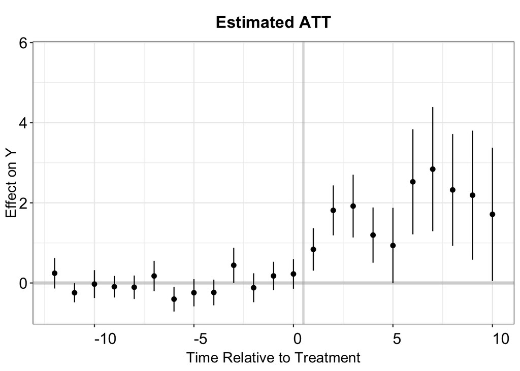

```r
fect.output <- as.data.frame(fect.output)
fect.output$Time <- c(-17:18)
p.fect <- esplot(fect.output,Period = 'Time',Estimate = 'ATT',
                   SE = 'S.E.',CI.lower = "CI.lower",
                   CI.upper = 'CI.upper',xlim = c(-12,10))
p.fect
```

### Compare with PanelMatch

To compare the results with those obtained via the `PanelMatch` method, `fect` also provides the capability to compute the ATT for the subset of the sample that includes units with 3 pre-treatment periods and 4 post-treatment periods. This can be achieved by specifying the option balance.period = c(-2,4), which denotes the range of periods to be included in the analysis (-2, -1, and 0 for pre-treatment, and 1, 2, 3, and 4 for post-treatment).

```r
out.fect.balance <- fect(nat_rate_ord~indirect, data = df, index = c("bfs","year"),
                         method = 'fe', se = TRUE, balance.period = c(-2,4))
#ATT
print(out.fect.balance$est.balance.avg)
```

```
#>       ATT.avg      S.E. CI.lower CI.upper      p.value
#> [1,] 1.711554 0.2088427  1.30223 2.120878 2.220446e-16
```

```r
#Dynamic Treatment Effects
```

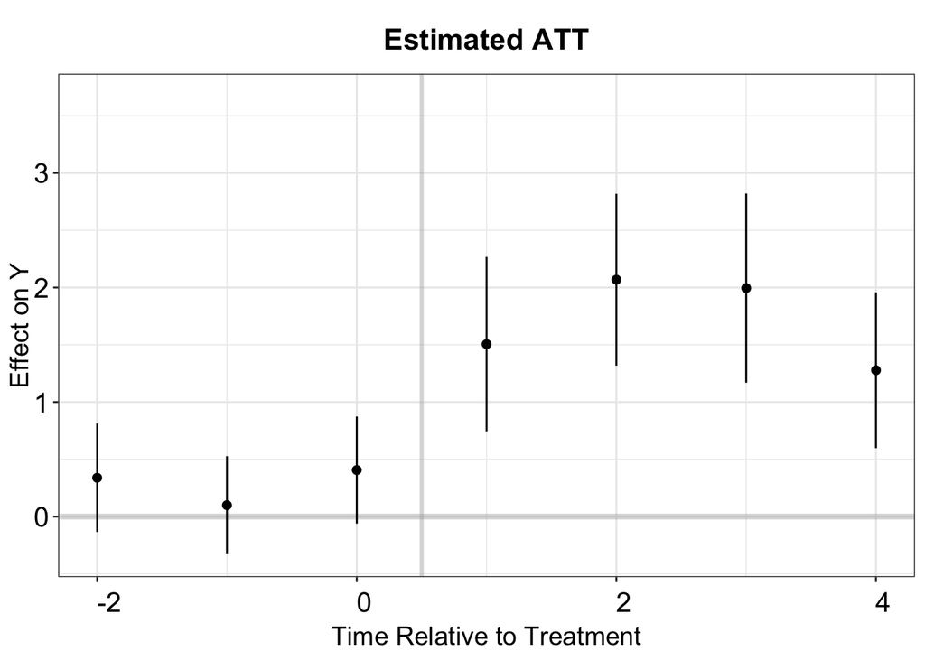

```r
fect.balance.output <- as.data.frame(out.fect.balance$est.balance.att)
fect.balance.output$Time <- c(-2:4)
p.fect.balance <- esplot(fect.balance.output,Period = 'Time',Estimate = 'ATT',
                   SE = 'S.E.',CI.lower = "CI.lower",
                   CI.upper = 'CI.upper')
p.fect.balance
```

# Example 2: w/ Treatment Reversal

We utilize the data from Grumbach and Sahn (2020) to demonstrate the analysis procedure when the treatment can switch on and off. The study, which uses district-election year level TSCS data from US House general elections between 1980 and 2012, argues that the presence of Asian (Black/Latino) candidates in general elections leads to an increase in the proportion of campaign contributions by Asian (Black/Latino) donors. Specifically, we focus on the effects of Asian candidates as presented in the top left panel of Figure 5 in the paper.

```r
data <- read.dta13(paste0(path, "grumbach-sahn_apsr2020_full.dta"))
data$cycle <- as.integer(as.numeric(data$cycle/2))
head(data)
```

```
#>   cycle district_final general_sharetotal_A_all general_sharetotal_B_all
#> 1   991            AK1              0.000000000               0.00000000
#> 2   992            AK1              0.000000000               0.05061753
#> 3   993            AK1              0.036166365               0.07233273
#> 4   994            AK1              0.015651902               0.01043460
#> 5   995            AK1              0.000000000               0.01882505
#> 6   996            AK1              0.006508764               0.03319470
#>   general_sharetotal_H_all cand_A_all cand_B_all cand_H_all dfe
#> 1              0.000000000          0          0          0   1
#> 2              0.000000000          0          0          0   1
#> 3              0.057866184          0          0          0   1
#> 4              0.005217301          0          0          0   1
#> 5              0.030926865          0          0          0   1
#> 6              0.019689011          0          0          0   1
```

## Data Visualization

In our analysis, the variable `district_final` and `cycle` serve as the unit and time index, respectively. The treatment variable is `cand_A_all`, the outcome of interest is `general_sharetotal_A_all`, and the covariates included in the analysis are `cand_H_all` and `cand_B_all`. To gain insight into the treatment conditions and missing values in the data, we utilize the **panelView** package. The option `by.timing = TRUE` is set in order to organize the units based on the timing of receiving the treatment. It should be noted that this dataset includes missingness in the outcome variable and the treatment may switch on and off.

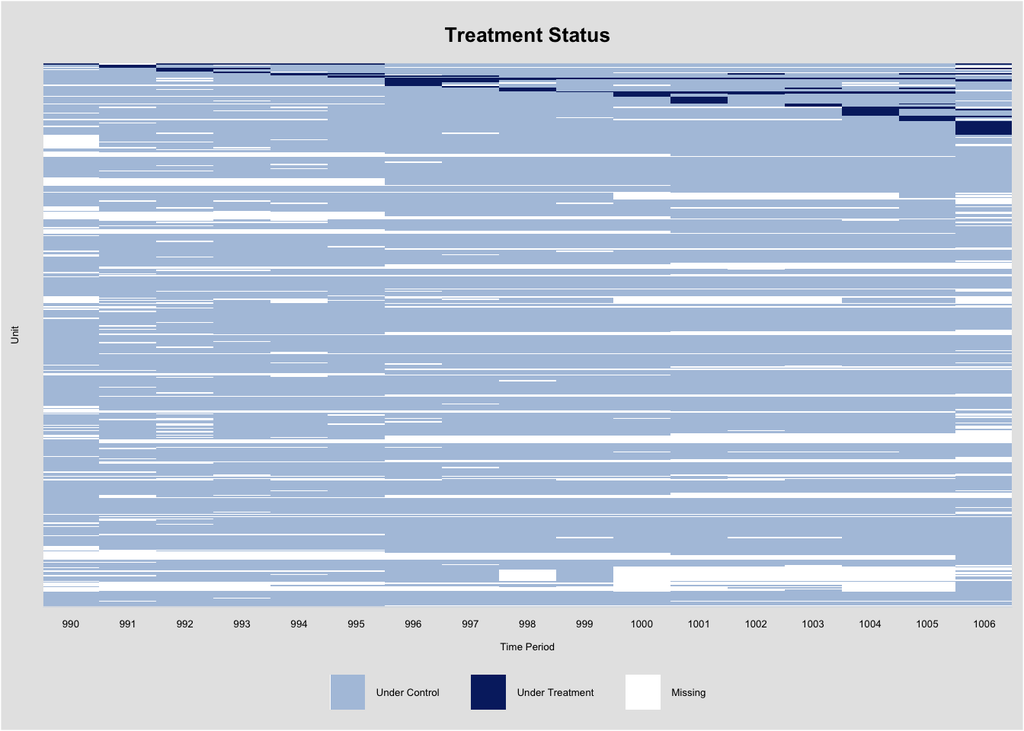

```r
y <- "general_sharetotal_A_all"
d <- "cand_A_all"
unit <- "district_final"
time <- "cycle"
controls <- c("cand_H_all", "cand_B_all")
index <- c("district_final", "cycle")

panelview(Y=y, D=d, X=controls, index = index, data = data, xlab = "Time Period", ylab = "Unit",
          gridOff = TRUE, by.timing = TRUE, cex.legend=5, cex.axis= 5, cex.main = 10, cex.lab = 5)
```

## TWFE

First, we obtain the ATT using the TWFE estimator.

```r
model.twfe <- feols(general_sharetotal_A_all ~ cand_A_all + cand_H_all + cand_B_all|district_final + cycle,
                    data=data, cluster = "district_final") #use the clustered standard error
print(model.twfe)
```

```
#> OLS estimation, Dep. Var.: general_sharetotal_A_all
#> Observations: 6,847
#> Fixed-effects: district_final: 489,  cycle: 17
#> Standard-errors: Clustered (district_final)
#>            Estimate Std. Error t value   Pr(>|t|)
#> cand_A_all 0.128098   0.025007 5.12256 4.3480e-07 ***
#> cand_H_all 0.012181   0.005274 2.30980 2.1316e-02 *
#> cand_B_all 0.010456   0.004594 2.27615 2.3269e-02 *
#> ---
#> Signif. codes:  0 '***' 0.001 '**' 0.01 '*' 0.05 '.' 0.1 ' ' 1
#> RMSE: 0.049535     Adj. R2: 0.275898
#>                  Within R2: 0.083964
```

### Event Study Plot

To estimate the dynamic treatment effects, we first utilize the function `get.cohort` to obtain the relative period to the treatment. We then generate the treated unit indicator `treat` by following these steps: First, we set `treat = 0` for observations of units that have never been treated. Second, for units that have been treated, if the treatment switches on and off, we only set `treat = 1` for observations prior to the last treatment exit, i.e., if a unit has the treatment status sequence as 0, 0, 0, 1, 1, 0, 0, we only set `treat = 1` for the first five observations. This procedure assumes no carryover treatment effects, meaning that the treatment only takes effect at the current period. Finally, we interact the dummy variable `treat` with the relative period index in a two-way fixed effects regression to estimate the dynamic treatment effects.

```r
data_cohort <- get.cohort(data, index = index, D=d)
# Generate a dummy variable treat
data_cohort$treat <- 0
data_cohort[which(data_cohort$Cohort!='Control'),'treat'] <- 1
data_cohort[which(is.na(data_cohort$Time_to_Treatment)), "treat"] <- 0

# remove observations that starts with treated status
remove <- intersect(which(is.na(data_cohort$Time_to_Treatment)), which(data_cohort[,d]==1))
if(length(remove)>0){data_cohort <- data_cohort[-remove,]}

# replace missingness in Time_to_Treatment with an arbitrary number
data_cohort[which(is.na(data_cohort$Time_to_Treatment)), "Time_to_Treatment"] <- 999

twfe.est <- feols(general_sharetotal_A_all ~ i(Time_to_Treatment, treat, ref = -1) +
                  cand_H_all +cand_B_all | district_final + cycle,
                  data = data_cohort, cluster = "district_final")
```

We then visualize the estimated dynamic treatment.

```r
twfe.output <- as.matrix(twfe.est$coeftable[c(1:25),])
print(twfe.output)
```

```
#>                                  Estimate  Std. Error    t value     Pr(>|t|)
#> Time_to_Treatment::-16:treat -0.014940426 0.023438304 -0.6374363 5.241396e-01
#> Time_to_Treatment::-15:treat -0.038164998 0.011362006 -3.3590017 8.434783e-04
#> Time_to_Treatment::-14:treat -0.035172442 0.010524624 -3.3419189 8.958865e-04
#> Time_to_Treatment::-13:treat -0.032246260 0.010475484 -3.0782598 2.199328e-03
#> Time_to_Treatment::-12:treat  0.003439330 0.028648925  0.1200509 9.044922e-01
#> Time_to_Treatment::-11:treat -0.021413340 0.017987605 -1.1904497 2.344485e-01
#> Time_to_Treatment::-10:treat -0.019647640 0.012642996 -1.5540335 1.208247e-01
#> Time_to_Treatment::-9:treat  -0.001535462 0.013341633 -0.1150880 9.084227e-01
#> Time_to_Treatment::-8:treat  -0.002309351 0.012435639 -0.1857043 8.527538e-01
#> Time_to_Treatment::-7:treat  -0.003408378 0.012370766 -0.2755188 7.830343e-01
#> Time_to_Treatment::-6:treat   0.016583110 0.018584831  0.8922927 3.726758e-01
#> Time_to_Treatment::-5:treat  -0.014949213 0.012092481 -1.2362404 2.169639e-01
#> Time_to_Treatment::-4:treat  -0.019672539 0.007123897 -2.7614858 5.970795e-03
#> Time_to_Treatment::-3:treat  -0.019037443 0.008972166 -2.1218337 3.435495e-02
#> Time_to_Treatment::-2:treat  -0.007612287 0.006002114 -1.2682677 2.053071e-01
#> Time_to_Treatment::0:treat    0.116367293 0.019291177  6.0321511 3.199576e-09
#> Time_to_Treatment::1:treat    0.133724736 0.045502782  2.9388255 3.450662e-03
#> Time_to_Treatment::2:treat    0.316864160 0.125811780  2.5185572 1.210235e-02
#> Time_to_Treatment::3:treat    0.198552123 0.043150455  4.6013912 5.357012e-06
#> Time_to_Treatment::4:treat    0.261498017 0.093699031  2.7908295 5.463286e-03
#> Time_to_Treatment::5:treat    0.155250352 0.027192716  5.7092625 1.972843e-08
#> Time_to_Treatment::6:treat    0.184621686 0.053799796  3.4316429 6.509094e-04
#> Time_to_Treatment::7:treat    0.192064488 0.024909842  7.7103857 7.095591e-14
#> Time_to_Treatment::8:treat    0.066716303 0.024755944  2.6949610 7.282539e-03
#> Time_to_Treatment::9:treat    0.042376250 0.024941526  1.6990239 8.995201e-02
```

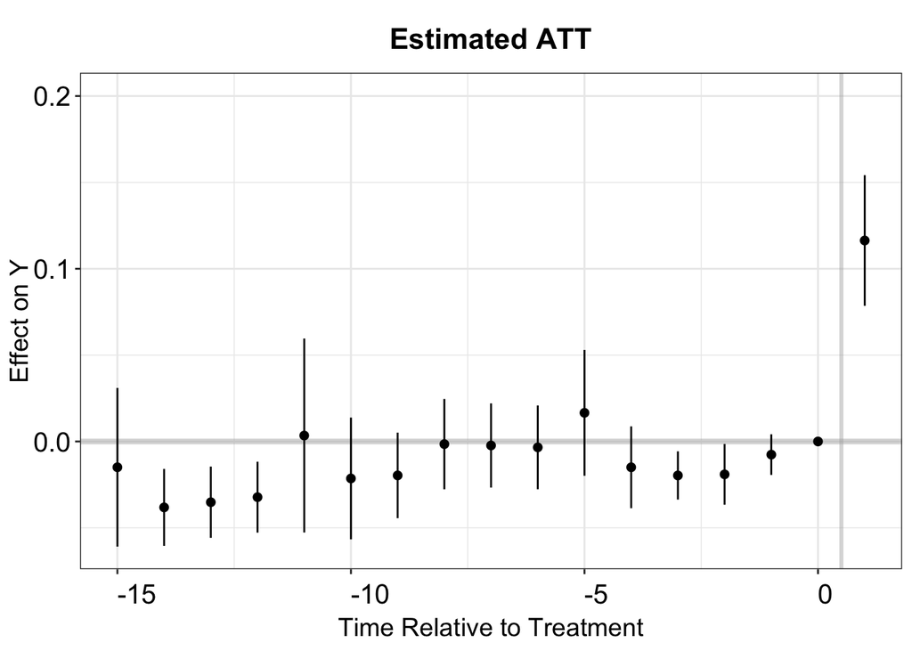

```r
twfe.output <- as.data.frame(twfe.output)
twfe.output$Time <- c(c(-16:-2),c(0:9))+1
p.twfe <- esplot(twfe.output,Period = 'Time',Estimate = 'Estimate',
                               SE = 'Std. Error', xlim = c(-15,1))
p.twfe
```

## PanelMatch

PanelMatch is also equipped to handle scenarios where the treatment can switch on and off. In this case, we will utilize a subset of the treated units that have two pre-treatment periods and one post-treatment period to calculate the average treatment effects.

```r
df.pm <- data_cohort
# we need to convert the unit and time indicator to integer
df.pm[,"district_final"] <- as.integer(as.factor(df.pm[,"district_final"]))
df.pm[,"cycle"] <- as.integer(as.factor(df.pm[,"cycle"]))
df.pm <- df.pm[,c("district_final","cycle","cand_A_all","general_sharetotal_A_all")]

PM.results <- PanelMatch(lag=2,
                         time.id="cycle",
                         unit.id = "district_final",
                         treatment = "cand_A_all",
                         refinement.method = "none",
                         data = df.pm,
                         qoi = "att",
                         lead = 0,
                         outcome.var = "general_sharetotal_A_all",
                         match.missing = TRUE)

## For pre-treatment dynamic effects
PM.results.placebo <- PanelMatch(lag=2,
                         time.id="cycle",
                         unit.id = "district_final",
                         treatment = "cand_A_all",
                         refinement.method = "none",
                         data = df.pm,
                         qoi = "att",
                         lead = 0,
                         outcome.var = "general_sharetotal_A_all",
                         match.missing = TRUE,
                         placebo.test = TRUE)
```

```r
# ATT
PE.results.pool <- PanelEstimate(PM.results, data = df.pm, pooled = TRUE)
summary(PE.results.pool)$summary
```

```
#> Matches created with 2 lags
#>
#> Standard errors computed with 1000 Weighted bootstrap samples
#>
#> Estimate of Average Treatment Effect on the Treated (ATT) by Period:
#>       estimate std.error       2.5%     97.5%
#> [1,] 0.1197584 0.0219985 0.07881666 0.1638193
```

### Event Study Plot

We obtain the dynamic treatment effects in the same way as we showed in the case of Hainmueller and Hangartner (2019).

```r
# Dynamic Treatment Effects
PE.results <- PanelEstimate(PM.results, data = df.pm)
PE.results.placebo <- placebo_test(PM.results.placebo, data = df.pm, plot = F)
```

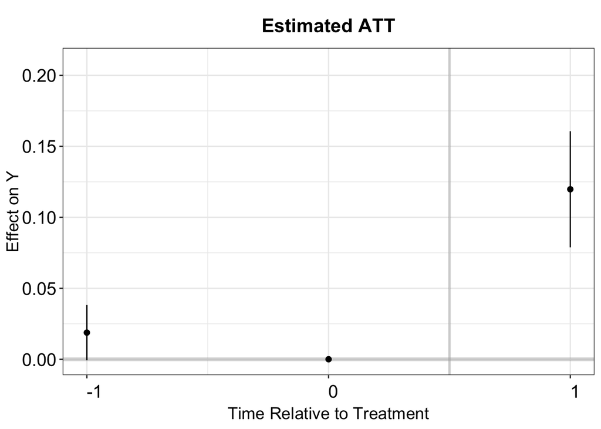

```r
est_lead <- as.vector(PE.results$estimates)
est_lag <- as.vector(PE.results.placebo$estimates)
sd_lead <- apply(PE.results$bootstrapped.estimates,2,sd)
sd_lag <- apply(PE.results.placebo$bootstrapped.estimates,2,sd)
coef <- c(est_lag, 0, est_lead)
sd <- c(sd_lag, 0, sd_lead)
pm.output <- cbind.data.frame(ATT=coef, se=sd, t=c(-1:1))
p.pm <- esplot(data = pm.output,Period = 't',
               Estimate = 'ATT',SE = 'se')
p.pm
```

## Imputation Method

The stacked DiD, iw estimator and csdid estimator do not account for treatment reversals. To estimate the average treatment effect (ATT) in scenarios where treatment can switch on and off, we employ the imputation method proposed by Liu, Wang, and Xu (2022), which accounts for treatment reversals and heterogeneous treatment effects.

```r
model.fect <- fect(Y = y, D = d, X= controls, data = data, method = "fe",
                   index = index, se = TRUE, parallel = TRUE, seed = 1234, force = "two-way")
print(model.fect$est.avg)
```

```
#>        ATT.avg       S.E.   CI.lower CI.upper      p.value
#> [1,] 0.1277491 0.02469477 0.07934829  0.17615 2.302096e-07
```

### Event Study Plot

We visualize the estimated dynamic treatment for the counterfactual estimator in the same way.

```r
fect.output <- as.matrix(model.fect$est.att)
print(fect.output)
```

```
#>               ATT        S.E.      CI.lower     CI.upper      p.value count
#> -15  0.0007768005 0.016832653 -0.0322145930  0.033768194 9.631919e-01    11
#> -14 -0.0211704682 0.006041969 -0.0330125107 -0.009328426 4.584942e-04    15
#> -13 -0.0197937240 0.006866693 -0.0332521951 -0.006335253 3.944454e-03    21
#> -12 -0.0161604498 0.006170367 -0.0282541474 -0.004066752 8.817714e-03    24
#> -11  0.0173223287 0.025022821 -0.0317214996  0.066366157 4.887733e-01    26
#> -10 -0.0101671188 0.013181064 -0.0360015294  0.015667292 4.405038e-01    32
#> -9  -0.0086394046 0.009699092 -0.0276492747  0.010370465 3.730667e-01    36
#> -8   0.0091411874 0.011105172 -0.0126245488  0.030906924 4.104245e-01    39
#> -7   0.0077375741 0.009057584 -0.0100149645  0.025490113 3.929584e-01    43
#> -6   0.0076803525 0.009904005 -0.0117311416  0.027091847 4.380564e-01    48
#> -5   0.0260877842 0.016026689 -0.0053239483  0.057499517 1.035734e-01    53
#> -4  -0.0052389859 0.010522568 -0.0258628410  0.015384869 6.185680e-01    56
#> -3  -0.0091852656 0.005278075 -0.0195301034  0.001159572 8.181198e-02    57
#> -2  -0.0099003105 0.007631375 -0.0248575308  0.005056910 1.945222e-01    62
#> -1   0.0006410009 0.005232789 -0.0096150766  0.010897078 9.025054e-01    65
#> 0    0.0166019901 0.008119382  0.0006882944  0.032515686 4.088092e-02    73
#> 1    0.1233181317 0.019883053  0.0843480634  0.162288200 5.568890e-10    74
#> 2    0.1389600839 0.044001797  0.0527181458  0.225202022 1.588257e-03    13
#> 3    0.3300925450 0.145937099  0.0440610865  0.616124004 2.370467e-02     5
#> 4    0.2025269124 0.070553138  0.0642453035  0.340808521 4.097473e-03     3
#> 5    0.2659320021 0.126480846  0.0180340988  0.513829905 3.550533e-02     3
#> 6    0.1591613175 0.025561200  0.1090622864  0.209260349 4.764340e-10     3
#> 7    0.1738020810 0.093887870 -0.0102147628  0.357818925 6.414560e-02     2
#> 8    0.1082956579 0.003457040  0.1015199848  0.115071331 0.000000e+00     1
#> 9   -0.0188593819 0.002655091 -0.0240632652 -0.013655499 1.219913e-12     1
#> 10  -0.0438930771 0.002543391 -0.0488780322 -0.038908122 0.000000e+00     1
```

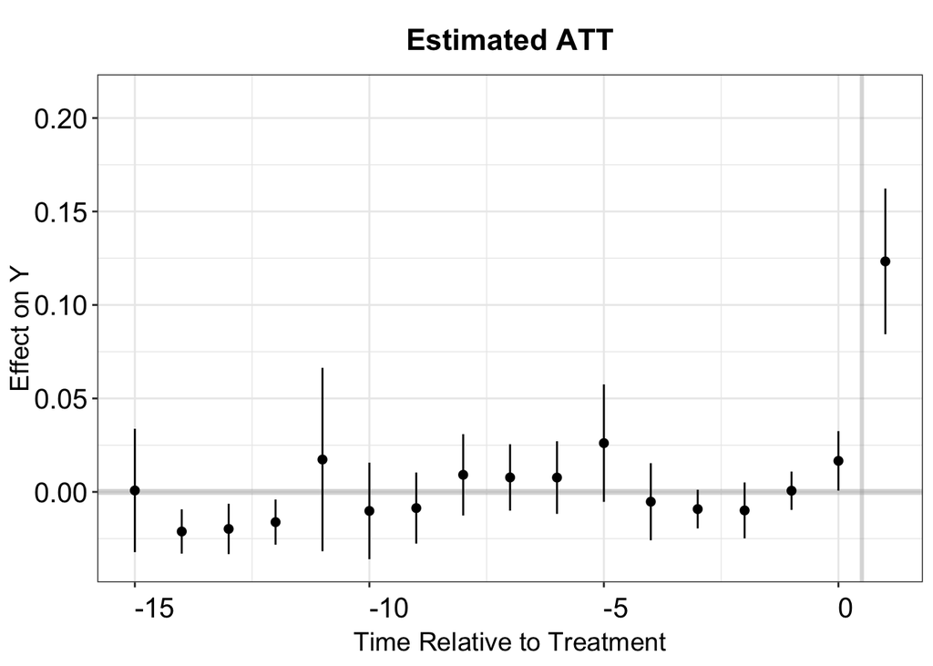

```r
fect.output <- as.data.frame(fect.output)
fect.output$Time <- c(-15:10)
p.fect <- esplot(fect.output,Period = 'Time',Estimate = 'ATT',
                   SE = 'S.E.',CI.lower = "CI.lower",
                   CI.upper = 'CI.upper', xlim = c(-15,1))
p.fect
```

The **plot** function shipped with **fect** can also visualize the estimated dynamic treatment effects.

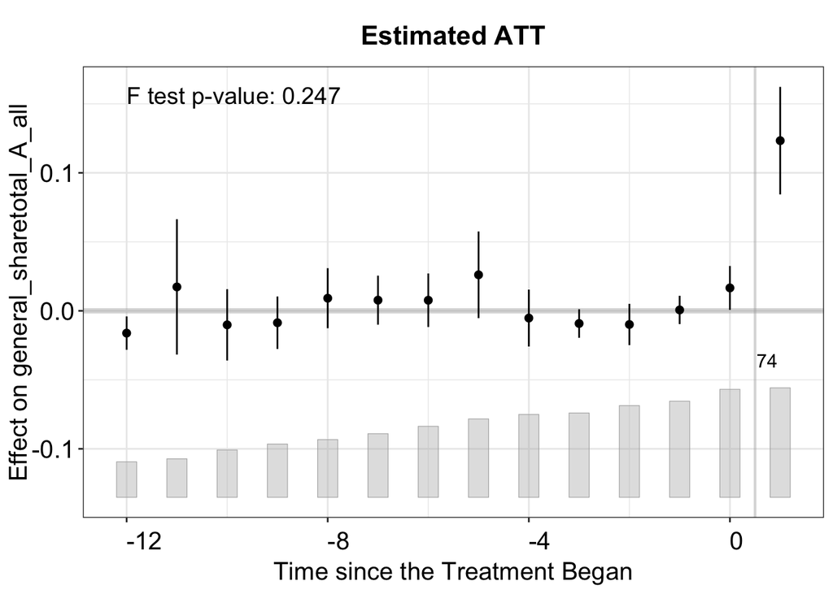

```r
plot(model.fect, stats = "F.p")
```

An $F$-test for the null hypothesis of zero residual averages in the pre-treatment periods yields a p-value greater than 0.1, providing insufficient evidence to reject the null hypothesis of zero pre-treatment average residuals.

We can visualize the period-wise ATTs relative to the **exit** of treatments by setting `type = "exit"`.

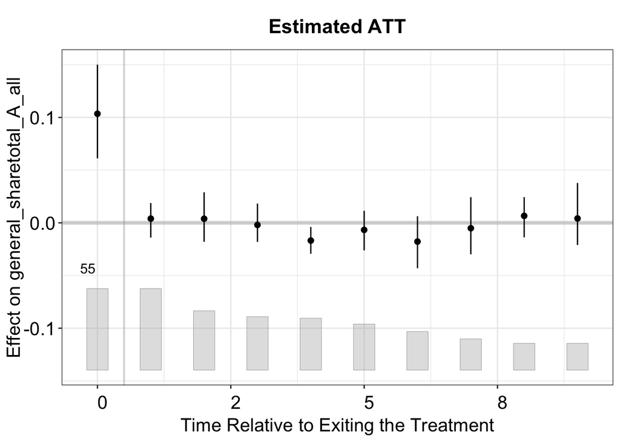

```r
plot(model.fect, stats = "F.p", type = 'exit')
```

### Diagnostic Tests

**Fect** also offers a placebo test function, which utilizes a subset of the data by removing observations in a specified range for model fitting, and subsequently assessing whether the estimated average treatment effect (ATT) in this range is statistically significant from zero. In this instance, we have set `placebo.period = c(-2, 0)`, indicating that the placebo periods will consist of the three periods preceding the onset of treatment.

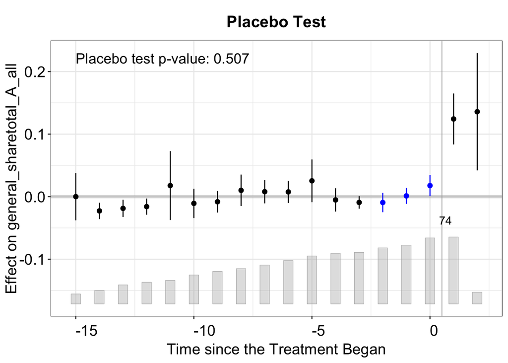

```r
out.fect.p <- fect(Y = y, X = controls, D = d, data = data, index = index,
                   method = 'fe', se = TRUE, placeboTest = TRUE, placebo.period = c(-2,0))
p.placebo <- plot(out.fect.p, proportion = 0.1, stats = "placebo.p")
p.placebo
```

*Test for (No) Carryover Effects*

The concept of the placebo test can be extended to examine the existence of carryover effects. Rather than obscuring a few periods immediately preceding the onset of treatment, this method involves obscuring a few periods immediately following the termination of treatment. If carryover effects do not exist, one would expect the average prediction error in these periods to be close to zero. To perform the carryover test, the option `carryoverTest = TRUE` is set. Additionally, a range of post-treatment periods can be specified in the option `carryover.period` to remove observations from this range for the purposes of model fitting, and then test whether the estimated Average Treatment Effect (ATT) in this range is significantly different from zero.

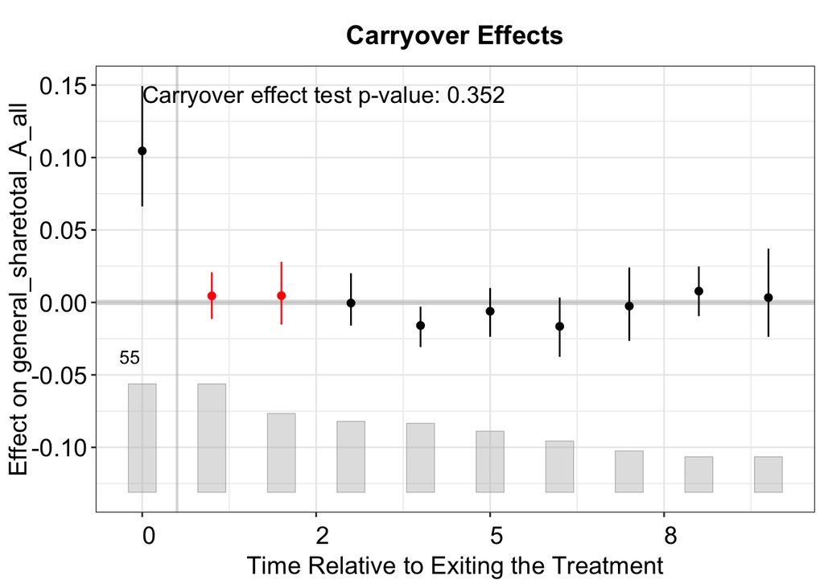

```r
out.fect.c <- fect(Y = y, X = controls, D = d, data = data, index = index,
                   method = 'fe', se = TRUE, carryoverTest = TRUE, carryover.period = c(1,2))
p.carryover <- plot(out.fect.c,  stats = "carryover.p")
p.carryover
```

### Compare with PanelMatch

We can compare it with the estimated ATT and dynamic treatment effects on the “balanced” sample using **fect**.

```r
out.fect.balance <- fect(Y = y, X = controls, D = d, data = data, index = index,
                         method = 'fe', se = TRUE, balance.period = c(-1,1))
#ATT
print(out.fect.balance$est.balance.avg)
```

```
#>        ATT.avg       S.E.   CI.lower  CI.upper      p.value
#> [1,] 0.1330911 0.02246486 0.08906074 0.1771214 3.134189e-09
```

```r
#Dynamic Treatment Effects
```

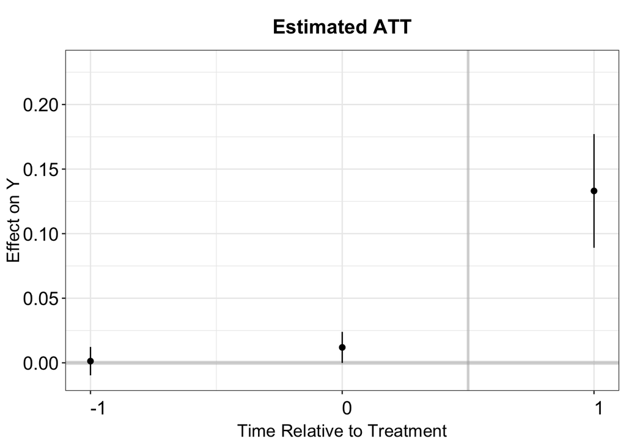

```r
fect.balance.output <- as.data.frame(out.fect.balance$est.balance.att)
fect.balance.output$Time <- c(-1:1)
p.fect.balance <- esplot(fect.balance.output,Period = 'Time',Estimate = 'ATT',
                   SE = 'S.E.',CI.lower = "CI.lower",
                   CI.upper = 'CI.upper')
p.fect.balance
```

# Reference

Bleiberg, Joshua. 2021. “STACKEDEV: Stata module to implement stacked event study estimator.” Statistical Software Components, Boston College Department of Economics. https://ideas.repec.org/c/boc/bocode/s459027.html.

Borusyak, Kirill, Xavier Jaravel, and Jann Spiess. 2021. “Revisiting Event Study Designs: Robust and Efficient Estimation,” August. https://arxiv.org/abs/2108.12419.

Callaway, Brantly, and Pedro HC Sant’Anna. 2021. “Difference-in-Differences with Multiple Time Periods.” *Journal of Econometrics* 225 (2): 200–230.

Cengiz, Doruk, Arindrajit Dube, Attila Lindner, and Ben Zipperer. 2019. “The Effect of Minimum Wages on Low-Wage Jobs*.” *The Quarterly Journal of Economics* 134 (3): 1405–54. https://doi.org/10.1093/qje/qjz014.

Chaisemartin, Clément de, and Xavier D’Haultfœuille. 2020. “Two-Way Fixed Effects Estimators with Heterogeneous Treatment Effects.” *The American Economic Review* 110 (9): 2964–96.

Gardner, John. 2021. “Two-Stage Differences in Differences.” https://bit.ly/3AF32Af.

Goodman-Bacon, Andrew. 2021. “Difference-in-Differences with Variation in Treatment Timing.” *Journal of Econometrics*.

Grumbach, Jacob M., and Alexander Sahn. 2020. “Race and Representation in Campaign Finance.” *American Political Science Review* 114 (1): 206–21. https://doi.org/10.1017/S0003055419000637.

Hainmueller, Jens, and Dominik Hangartner. 2019. “Does Direct Democracy Hurt Immigrant Minorities? Evidence from Naturalization Decisions in Switzerland.” *American Journal of Political Science* 63 (3): 530–47.

Imai, Kosuke, In Song Kim, and Erik Wang. 2021. “Matching Methods for Causal Inference with Time-Series Cross-Section Data.” *American Journal of Political Science*, no. forthcoming.

Liu, Licheng, Ye Wang, and Yiqing Xu. 2022. “A Practical Guide to Counterfactual Estimators for Causal Inference with Time-Series Cross-Sectional Data.” *American Jouranl of Political Science*, no. forthcoming.

Sun, Liyang, and Sarah Abraham. 2021. “Estimating Dynamic Treatment Effects in Event Studies with Heterogeneous Treatment Effects.” *Journal of Econometrics* 225 (2): 175–99.

[interactive chart not shown]